# COVID-19 Cases in Hong Kong

Qixiao Zhong

```r
# clean up the RStudio environment
rm(list = ls())
```

```r
# load all packages here: `mosaic`, `tidyverse`, `lubridate`, and all others used
library(mosaic)
library(tidyverse)
library(lubridate)
library(jsonlite)
library(leaflet)
```

### Data Intake

The following data of COVID-19 inaction cases in Hong Kong is from DATA.GOV.HK, a web interface provided by the Office of the Government Chief Information Officer of the Government of the Hong Kong Special Administrative Region to the public for obtaining certain public sector information. The data from the site are open for development or analysis.

```r
cases <- read.csv("https://www.chp.gov.hk/files/misc/enhanced_sur_covid_19_eng.csv")
cases <- cases %>% transmute(
  caseID = Case.no.,
  reportDate = dmy(Report.date),
  onsetDate = dmy(Date.of.onset),
  sex = Gender,
  age = as.numeric(Age),
  hospital = Name.of.hospital.admitted,
  status = Hospitalised.Discharged.Deceased,
  citizenship = HK.Non.HK.resident,
  caseSource = Case.classification.,
  confidence = Confirmed.probable
)
cases
```

| caseID | reportDate | onsetDate | sex | age | hospital | status | citizenship | caseSource | confidence |
| --- | --- | --- | --- | --- | --- | --- | --- | --- | --- |
| 1 | 2020-01-23 | 2020-01-21 | M | 39 | Princess Margaret Hospital | Discharged | Non-HK resident | Imported | Confirmed |
| 2 | 2020-01-23 | 2020-01-18 | M | 56 | Princess Margaret Hospital | Discharged | HK resident | Imported | Confirmed |
| 3 | 2020-01-24 | 2020-01-20 | F | 62 | Princess Margaret Hospital | Discharged | Non-HK resident | Imported | Confirmed |
| 4 | 2020-01-24 | 2020-01-23 | F | 62 | Princess Margaret Hospital | Discharged | Non-HK resident | Imported | Confirmed |
| 5 | 2020-01-24 | 2020-01-23 | M | 63 | Princess Margaret Hospital | Discharged | Non-HK resident | Imported | Confirmed |
| 6 | 2020-01-26 | 2020-01-21 | M | 47 | Princess Margaret Hospital | Discharged | HK resident | Imported | Confirmed |
| 7 | 2020-01-26 | 2020-01-21 | F | 68 | Princess Margaret Hospital | Discharged | HK resident | Imported | Confirmed |
| 8 | 2020-01-26 | 2020-01-25 | M | 64 | Princess Margaret Hospital | Discharged | Non-HK resident | Imported | Confirmed |
| 9 | 2020-01-29 | 2020-01-25 | F | 73 | Princess Margaret Hospital | Discharged | Non-HK resident | Imported | Confirmed |
| 10 | 2020-01-29 | 2020-01-25 | M | 72 | Princess Margaret Hospital | Discharged | Non-HK resident | Imported | Confirmed |

[output cut: 990 more lines]

**So far on April 21, 2020, there are 1026 COVID-19 cases in Hong Kong.**

Another data source from DATA.GOV.HK is about the buildings in which probable/confirmed cases have been in the past 14 days.

```r
buildings <- read.csv("https://www.chp.gov.hk/files/misc/building_list_eng.csv")
buildings <- buildings %>% separate_rows(Related.probable.confirmed.cases) %>% transmute(
  district = as.character(District),
  buildingName = as.character(Building.name),
  caseID = as.integer(Related.probable.confirmed.cases)
) %>% na.omit()
buildings
```

|  | district | buildingName | caseID |
| --- | --- | --- | --- |
| 1 | Wan Chai | The Park Lane Hong Kong, a Pullman Hotel | 892 |
| 2 | Yuen Long | Orchid Path, The Westwood, (Phase 1C), Palm Springs | 893 |
| 3 | Central & Western | Borrett Mansions | 894 |
| 4 | Kowloon City | Kensington House | 895 |
| 5 | Sha Tin | Tower 1, Festival City (Phase 2) | 896 |
| 6 | Central & Western | Tower 2, Island Crest | 897 |
| 7 | North | Ha Shan Kai Wat | 898 |
| 8 | Central & Western | Lexington Hill | 899 |
| 9 | Central & Western | Robinson Place | 900 |
| 10 | Wan Chai | Winfield Gardens | 901 |

[output cut: 274 more lines]

One more data source from DATA.GOV.HK tracks the flights (or other vehicles) taken by probable/confirmed cases of COVID-19 in the past 14 days.

```r
flights <- read.csv("http://www.chp.gov.hk/files/misc/flights_trains_list_eng.csv")
flights <- flights %>% transmute(
  number = Flight.Train.Ship.number,
  departure = Departure...arrival,
  date = Date.of.travel,
  caseID = Related.probable.confirmed.cases
)
flights
```

| number | departure | date | caseID |
| --- | --- | --- | --- |
| CX252 | London | 06/04/2020 | 927 |
| CX881 | Los Angeles | 06/04/2020 | 938 |
| VS206 | London | 06/04/2020 | 962 |
| VS206 | London | 06/04/2020 | 963 |
| VS206 | London | 06/04/2020 | 969 |
| CX252 | London | 07/04/2020 | 982 |
| CX252 | London | 07/04/2020 | 993 |
| CX252 | London | 07/04/2020 | 1009 |
| CX252 | London | 08/04/2020 | 967 |
| CX906 | Manila | 08/04/2020 | 981 |

[output cut: 28 more lines]

### Age of Cases

```r
# Number of cases for male and female
cases %>% filter(confidence == "Confirmed") %>% group_by(sex) %>% summarise(total = n())
```

| sex | total |
| --- | --- |
| F | 474 |
| M | 551 |

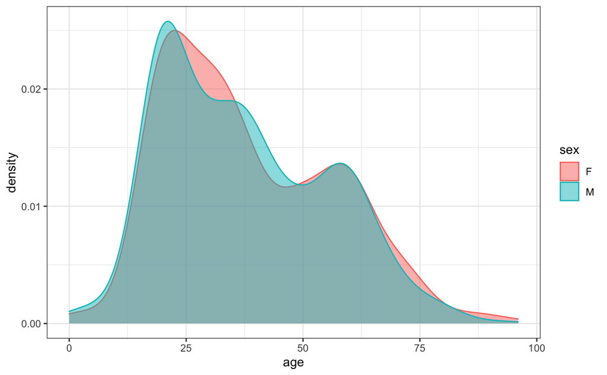

```r
# Distribution plot
cases %>% filter(confidence == "Confirmed") %>%
  ggplot(aes(x = age, color = sex)) + geom_density(aes(fill = sex), alpha = 0.5) +
  theme_bw()
```

The age distribution does not depends on sex so much, and the age of cases is most likely about 20.

### Current Status of Confirmed Cases

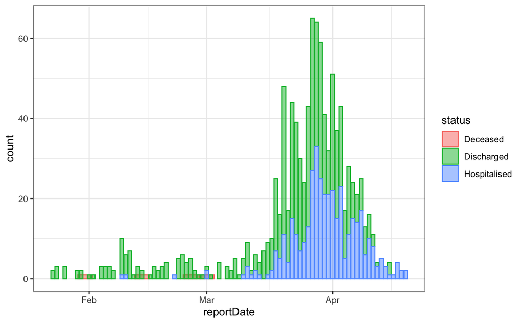

```r
cases %>% filter(confidence == "Confirmed") %>%
  ggplot(aes(x = reportDate, color = status)) + geom_bar(aes(fill = status), alpha = .5, ) +
  theme_bw()
```

### Source of Confirmed Cases

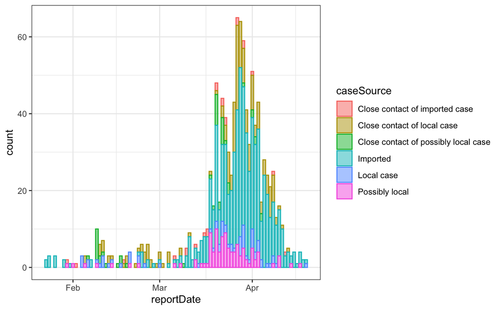

```r
cases %>% filter(confidence == "Confirmed") %>%
  ggplot(aes(x = reportDate, color = caseSource)) + geom_bar(aes(fill = caseSource), alpha = .5) +
  theme_bw()
```

Encountering the global pandemic of COVID-19, many people flied back to the city (including me) in the recent month, bringing hundreds of imported cases.

### Where are the Imported Cases in the Past 14 Days from?

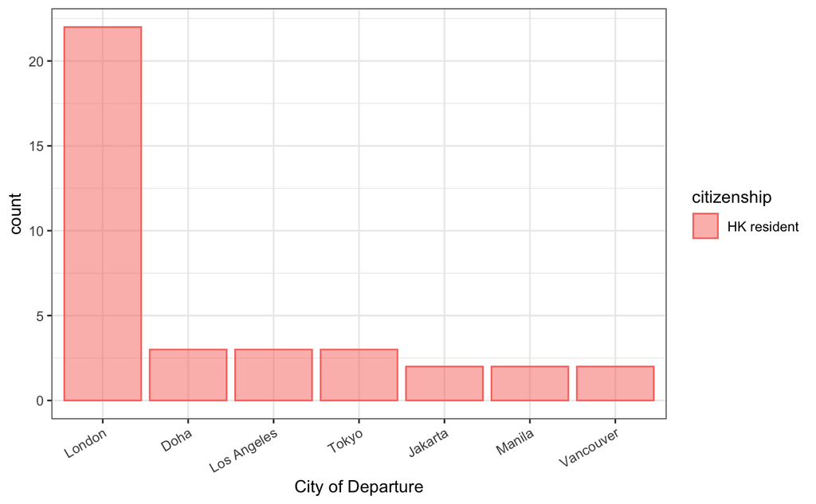

```r
flights %>% inner_join(flights %>% group_by(departure) %>% summarise(count = n()), by = "departure") %>%
  inner_join(cases, by = "caseID") %>% filter(count > 1) %>%
  ggplot(aes(fill = citizenship, color = citizenship)) + geom_bar(aes(x = reorder(departure, desc(count))), alpha = .5) +
  theme_bw() + theme(axis.text.x = element_text(angle = 30, hjust = 1)) + xlab("City of Departure")
```

### Where have the confirmed cases resided in the past 14 days?

```r
getHKLocation <- function(street, district) {
  addr <- paste(street, district, "HK", sep = ", ")
  addr <- gsub(pattern = " ", replacement = "%20", addr)
  addr <- gsub(pattern = ",", replacement = "%2C", addr)
  addr <- gsub(pattern = "&", replacement = "%26", addr)
  url <- paste("https://api.opencagedata.com/geocode/v1/json?q=", addr,
              "&countrycode=hk%2Ccn&key=790d95dc016e4dbe8e71786011ab7c6a", sep = "")
  geo <- fromJSON(url)$results$geometry %>% head(1)
  return(c(geo$lng, geo$lat))
}
buildings <- buildings %>% mutate(longitude = NA, latitude = NA)
```

Get lattitude and longitude for buildings from *OpenCage Geocoder*. Running this code chunk takes long time.

```r
for(i in 245:as.integer(count(buildings))) {
  loc <- getHKLocation(buildings$buildingName[i], buildings$district[i])
  if (length(loc) > 0) {
    buildings$longitude[i] <- loc[1]
    buildings$latitude[i] <- loc[2]
  }
}
```

Use `leaflet` to plot the locations of where confirmed cases have been lived.

```r
buildingsMap <-
  buildings %>% na.omit() %>% group_by(longitude, latitude) %>% summarise(count = n()) %>%
  leaflet() %>%
  addTiles() %>%
  setView(114.15, 22.37, zoom = 11) %>%
  addCircleMarkers(weight = 1, radius = ~ 3 * sqrt(count), color = "red", popup = ~ paste(count, "cases"), fillOpacity = .5)
buildingsMap
```

[interactive chart not shown]

Most locations are near down town, which is not surprising.

[**Home**](https://qfz5040.github.io/COVID-19-cases-hk/)